# Notes: Bioconductor for Genomic Data Science

Kiara

2025-04-27

**Course 5 -> Bioconductor for Genomic Data Science**

Course link: https://www.coursera.org/learn/bioconductor?specialization=genomic-data-science

Course GitHub page: http://kasperdanielhansen.github.io/genbioconductor/

> `BiocManager::install("name")` to install a package inside Bioconductor!!!!

## GRanges

**GRanges is a data structure for storing genomic intervals in R**. The key insight is that many entities in genomics can be thought of intervals or sets of intervals (of integers). The functionality of GRanges is provided by two packages: GenomicRanges and IRanges.

### IRanges

The IRanges object contains integer intervals, **each called a range**. Three arguments for construction: start, end, and width (one of them can be inferred given the other two).

```r
library(IRanges)
ir1 <- IRanges(start = c(1,4,5), end = c(3,5,20))
print(ir1)
```

```
## IRanges object with 3 ranges and 0 metadata columns:
##           start       end     width
##       <integer> <integer> <integer>
##   [1]         1         3         3
##   [2]         4         5         2
##   [3]         5        20        16
```

```r
print(class(ir1))
```

```
## [1] "IRanges"
## attr(,"package")
## [1] "IRanges"
```

```r
# Accessing the start positions of these intervals (ranges)
print(start(ir1))
```

```
## [1] 1 4 5
```

```r
width(ir1) <- 1 # Note that it's an interger interval so the width of one range should be (end - start +1).
print(ir1)
```

```
## IRanges object with 3 ranges and 0 metadata columns:
##           start       end     width
##       <integer> <integer> <integer>
##   [1]         1         1         1
##   [2]         4         4         1
##   [3]         5         5         1
```

```r
# IRanges can have names like any other vector. And since IRanges is a vector-like object (tho it looks like a matrix sadly; it's 'vector'-like under the R context), they don't have a dimension but instead have a length, which is the number of ranges it has.
names(ir1) = paste("A", 1:3, sep='')
ir1
```

```
## IRanges object with 3 ranges and 0 metadata columns:
##          start       end     width
##      <integer> <integer> <integer>
##   A1         1         1         1
##   A2         4         4         1
##   A3         5         5         1
```

```r
dim(ir1)
```

[output not shown]

```r
length(ir1) # Equal to the number of ranges
```

```
## [1] 3
```

```r
ir1['A2'] # Accessing a range by its name (just like accessing an element in a vector)
```

```
## IRanges object with 1 range and 0 metadata columns:
##          start       end     width
##      <integer> <integer> <integer>
##   A2         4         4         1
```

```r
c(ir1,ir1) # Concatenating multiple IRanges, again, just like doing so to any vectors.
```

```
## IRanges object with 6 ranges and 0 metadata columns:
##          start       end     width
##      <integer> <integer> <integer>
##   A1         1         1         1
##   A2         4         4         1
##   A3         5         5         1
##   A1         1         1         1
##   A2         4         4         1
##   A3         5         5         1
```

A **normal IRanges**: (easier to be understood using a plot) created by `reduce(IRanges)`, a **minimal representation** of the IRanges viewed as a set of integers, with each integer only occurring in a single range as few ranges present as possible. With this concept in mind we can more easily think of operations to multiple IRanges like `union` (equivalent to first concatenating the IRanges together and then `reduce()` that new object), `intersect`, and `setdiff`.

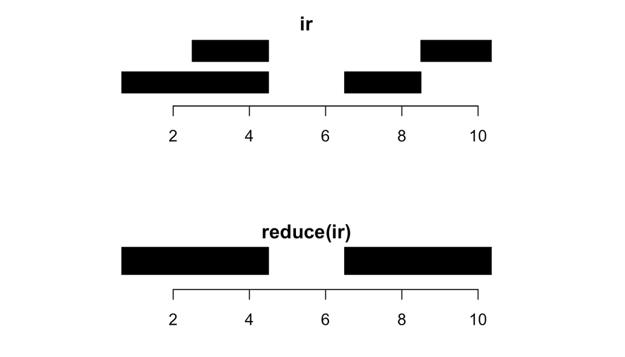

https://kasperdanielhansen.github.io/genbioconductor/html/IRanges_Basic.html#normal-iranges

These functions (and the concept of normal IRanges; this *flattened* feeling) are very useful using eg. `sum(width(union(GRanges1, GRanges2, ignore.strand = TRUE)))` to quickly see how much the genomic entities of interest span, as demonstrated in a demo later on.

```r
ir2 <- IRanges(start = c(4,5,9,24), end = c(5,20,13,26))
ir2
```

```
## IRanges object with 4 ranges and 0 metadata columns:
##           start       end     width
##       <integer> <integer> <integer>
##   [1]         4         5         2
##   [2]         5        20        16
##   [3]         9        13         5
##   [4]        24        26         3
```

```r
reduce(ir2)
```

```
## IRanges object with 2 ranges and 0 metadata columns:
##           start       end     width
##       <integer> <integer> <integer>
##   [1]         4        20        17
##   [2]        24        26         3
```

```r
ir1
```

```
## IRanges object with 3 ranges and 0 metadata columns:
##          start       end     width
##      <integer> <integer> <integer>
##   A1         1         1         1
##   A2         4         4         1
##   A3         5         5         1
```

```r
union(ir1,ir2)
```

```
## IRanges object with 3 ranges and 0 metadata columns:
##           start       end     width
##       <integer> <integer> <integer>
##   [1]         1         1         1
##   [2]         4        20        17
##   [3]        24        26         3
```

```r
intersect(ir1,ir2)
```

```
## IRanges object with 1 range and 0 metadata columns:
##           start       end     width
##       <integer> <integer> <integer>
##   [1]         4         5         2
```

```r
# How the two sets differed.
setdiff(ir1,ir2)
```

```
## IRanges object with 1 range and 0 metadata columns:
##           start       end     width
##       <integer> <integer> <integer>
##   [1]         1         1         1
```

```r
setdiff(ir2, ir1)
```

```
## IRanges object with 2 ranges and 0 metadata columns:
##           start       end     width
##       <integer> <integer> <integer>
##   [1]         6        20        15
##   [2]        24        26         3
```

Resizing IRanges:

```r
ir1
```

```
## IRanges object with 3 ranges and 0 metadata columns:
##          start       end     width
##      <integer> <integer> <integer>
##   A1         1         1         1
##   A2         4         4         1
##   A3         5         5         1
```

```r
resize(ir1, width = 3, fix = 'start')
```

```
## IRanges object with 3 ranges and 0 metadata columns:
##          start       end     width
##      <integer> <integer> <integer>
##   A1         1         3         3
##   A2         4         6         3
##   A3         5         7         3
```

```r
resize(ir1, width = 3, fix = 'center') # This is more useful
```

```
## IRanges object with 3 ranges and 0 metadata columns:
##          start       end     width
##      <integer> <integer> <integer>
##   A1         0         2         3
##   A2         3         5         3
##   A3         4         6         3
```

#### findOverlaps()

Allow us to relate sets of IRanges to each other. (different from the `intersect` function above, which requires to think of IRanges as flattened (?) sets of integers)

```r
ir1
```

```
## IRanges object with 3 ranges and 0 metadata columns:
##          start       end     width
##      <integer> <integer> <integer>
##   A1         1         1         1
##   A2         4         4         1
##   A3         5         5         1
```

```r
ir2
```

```
## IRanges object with 4 ranges and 0 metadata columns:
##           start       end     width
##       <integer> <integer> <integer>
##   [1]         4         5         2
##   [2]         5        20        16
##   [3]         9        13         5
##   [4]        24        26         3
```

```r
# Note that the returned 'Hits' indicate in which specific range (its index) of the two IRanges objects this overlap is found.
findOverlaps(query = ir1, subject = ir2)
```

```
## Hits object with 3 hits and 0 metadata columns:
##       queryHits subjectHits
##       <integer>   <integer>
##   [1]         2           1
##   [2]         3           1
##   [3]         3           2
##   -------
##   queryLength: 3 / subjectLength: 4
```

```r
# Counts how many overlaps found in that specific range
countOverlaps(query = ir1, subject = ir2)
```

```
## A1 A2 A3
##  0  1  2
```

```r
countOverlaps(subject = ir1, query = ir2)
```

```
## [1] 2 1 0 0
```

```r
nearest(ir2, subject = ir1) # Returns which ranges in the 'subject' are nearest to the corresponding ranges of the IRanges object in the first argument
```

[output not shown]

### GRanges and the GenomicRanges Package

`GRanges()` is the GRanges constructor, which is very similar to `IRanges()`; it also has to do with chromosomes (in ‘seqnames’) and +/- strands (’*’ means it’s either unknown or the entity is on both strands).

```r
library(GenomicRanges)
gr = GRanges(seqnames = c("chr1"), strand = c("+","-","+","*"), ranges = IRanges(start = c(1,1,5,3), width = 3))
gr
```

```
## GRanges object with 4 ranges and 0 metadata columns:
##       seqnames    ranges strand
##          <Rle> <IRanges>  <Rle>
##   [1]     chr1       1-3      +
##   [2]     chr1       1-3      -
##   [3]     chr1       5-7      +
##   [4]     chr1       3-5      *
##   -------
##   seqinfo: 1 sequence from an unspecified genome; no seqlengths
```

*New operations* are now involved due to the opposite directions of two strands.

```r
gr
```

```
## GRanges object with 4 ranges and 0 metadata columns:
##       seqnames    ranges strand
##          <Rle> <IRanges>  <Rle>
##   [1]     chr1       1-3      +
##   [2]     chr1       1-3      -
##   [3]     chr1       5-7      +
##   [4]     chr1       3-5      *
##   -------
##   seqinfo: 1 sequence from an unspecified genome; no seqlengths
```

```r
flank(gr, width = 5) # Note the difference for ranges on different strands!!
```

```
## GRanges object with 4 ranges and 0 metadata columns:
##       seqnames    ranges strand
##          <Rle> <IRanges>  <Rle>
##   [1]     chr1      -4-0      +
##   [2]     chr1       4-8      -
##   [3]     chr1       0-4      +
##   [4]     chr1      -2-2      *
##   -------
##   seqinfo: 1 sequence from an unspecified genome; no seqlengths
```

```r
promoters(gr) # Default is upstream 2000 bp and downstream 200 bp of our interval (our range).
```

```
## GRanges object with 4 ranges and 0 metadata columns:
##       seqnames    ranges strand
##          <Rle> <IRanges>  <Rle>
##   [1]     chr1 -1999-200      +
##   [2]     chr1 -196-2003      -
##   [3]     chr1 -1995-204      +
##   [4]     chr1 -1997-202      *
##   -------
##   seqinfo: 1 sequence from an unspecified genome; no seqlengths
```

```r
gaps(gr) # Returns all intervals not covered by our IRanges; we haven't set the length of the chromosome (the seqlengths) yet so it assumes that the end of the interval is the end of the full seq. Here we can infer that the genomic coordinates are 1-based.
```

```
## GRanges object with 2 ranges and 0 metadata columns:
##       seqnames    ranges strand
##          <Rle> <IRanges>  <Rle>
##   [1]     chr1         4      +
##   [2]     chr1       1-2      *
##   -------
##   seqinfo: 1 sequence from an unspecified genome; no seqlengths
```

In later demos we will retrieve GRanges after querying genes of interest from AnnotationHub. For a GRanges that contains a super large collection of ranges, we can use functions for a quick overview (but here we’ll still use our `gr` to illustrate the use of these functions)

```r
summary(width(gr))
```

```
##    Min. 1st Qu.  Median    Mean 3rd Qu.    Max.
##       3       3       3       3       3       3
```

```r
summary(end(gr))
```

```
##    Min. 1st Qu.  Median    Mean 3rd Qu.    Max.
##     3.0     3.0     4.0     4.5     5.5     7.0
```

```r
# Counts occurrences of values
table(end(gr))
```

```
##
## 3 5 7
## 2 1 1
```

```r
table(gr$score)
```

```
## < table of extent 0 >
```

```r
table(table(gr$score))
```

```
## < table of extent 0 >
```